# Lab 3: Transformations and Model Improvement

MATH 4780 / MSSC 5780 Regression Analysis

Author

Mehdi Maadooliat

**NoteCourse data**

This lab uses objects in `regression_datasets.rda`. Put the `.qmd` file and `regression_datasets.rda` in the same folder before rendering or working through the lab.

## Learning goals

**NoteConnection to model adequacy**

Use transformations only after examining the original-scale relationship and diagnostics. A useful transformation should improve the **structure of the model** (linearity, variance stability, or error behavior) and remain interpretable in the application.

Recognize when a transformation may improve a regression model, compare candidate transformations graphically, and use the Box-Cox profile as a systematic guide.

```r
library(ggplot2)
library(dplyr)
library(MASS)
```

## 1. Electric utility data

The `electric_utility` object comes from the older course materials. Begin by checking its variable names.

```r
names(electric_utility)
```

```
[1] "usage_kwh"   "demand_kw"   "sqrt_demand"
```

```r
head(electric_utility)
```

```
  usage_kwh demand_kw sqrt_demand
1       679      0.79       0.889
2       292      0.44       0.663
3      1012      0.56       0.748
4       493      0.79       0.889
5       582      2.70       1.643
6      1156      3.64       1.908
```

For this lab, the first column is electricity use (x) and the second is peak demand (y). We create local names so the analysis is robust to descriptive column names in the course file.

```r
utility <- data.frame(
  x = electric_utility[[1]],
  y = electric_utility[[2]]
)
```

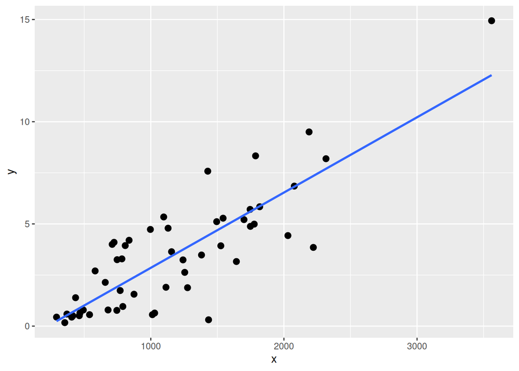

```r
ggplot(utility, aes(x, y)) +
  geom_point(size = 2.5) +
  geom_smooth(method = "lm", se = FALSE)
```

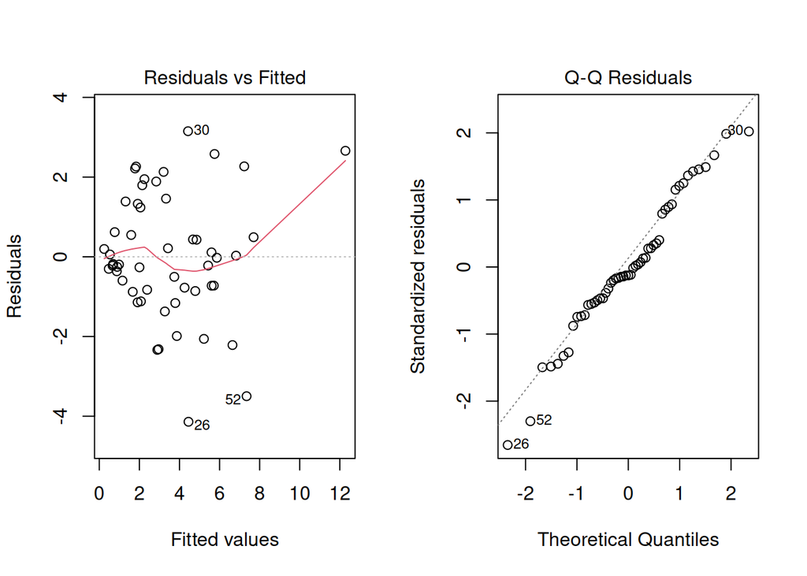

```r
fit0 <- lm(y ~ x, data = utility)
par(mfrow = c(1, 2))
plot(fit0, which = 1)
plot(fit0, which = 2)
```

```r
par(mfrow = c(1, 1))
```

What evidence suggests that the original-scale model may be inadequate?

## 2. Try common response transformations

```r
utility <- utility |>
  mutate(
    sqrt_y = sqrt(y),
    log_y = log(y)
  )
```

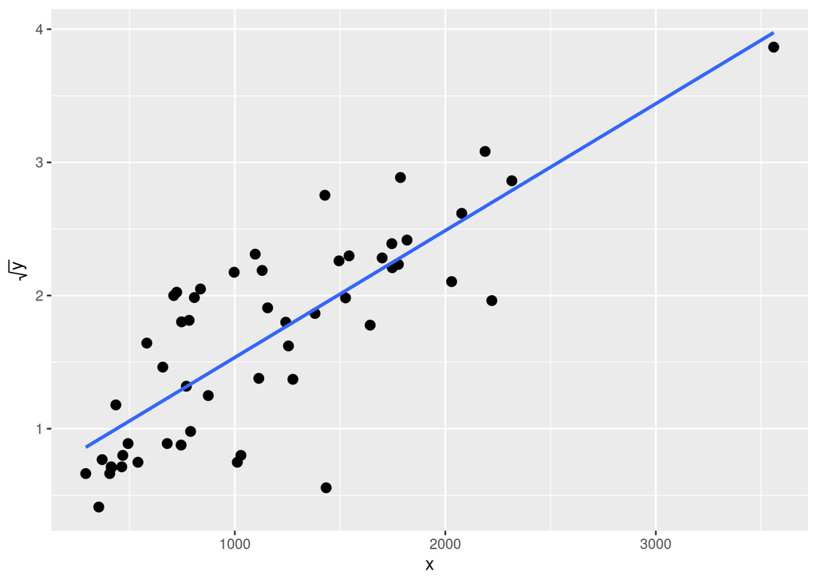

```r
ggplot(utility, aes(x, sqrt_y)) +
  geom_point(size = 2.5) +
  geom_smooth(method = "lm", se = FALSE) +
  labs(y = expression(sqrt(y)))
```

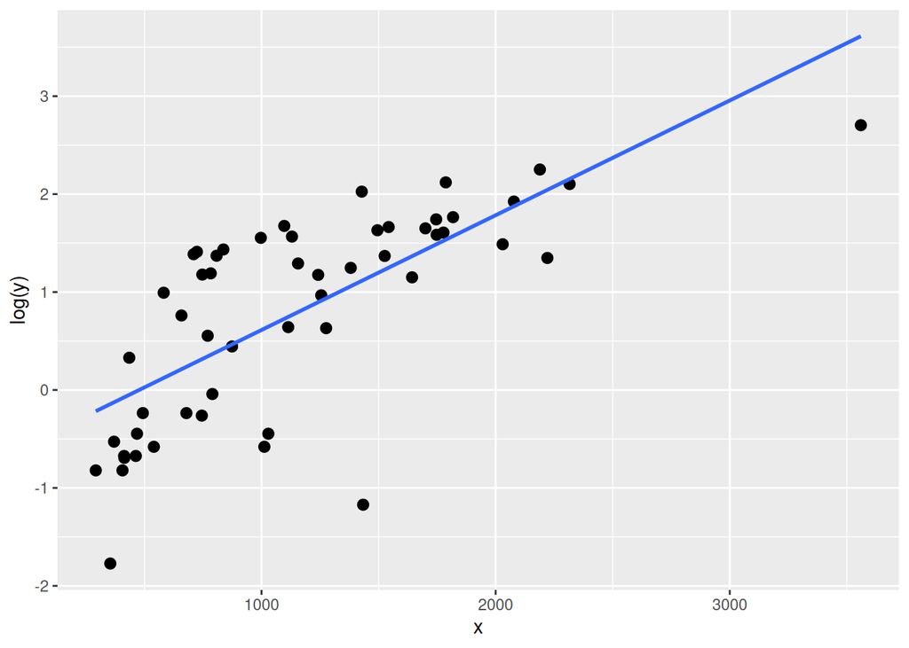

```r
ggplot(utility, aes(x, log_y)) +
  geom_point(size = 2.5) +
  geom_smooth(method = "lm", se = FALSE) +
  labs(y = "log(y)")
```

Which transformation gives the most nearly linear relationship and the most stable spread?

## 3. Compare diagnostics

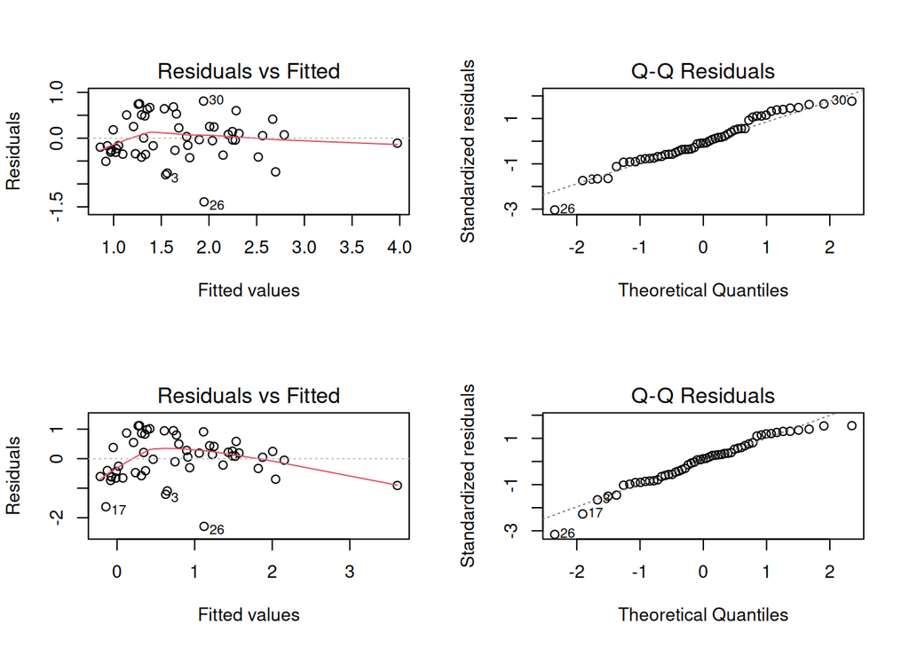

```r
fit_sqrt <- lm(sqrt(y) ~ x, data = utility)
fit_log  <- lm(log(y) ~ x, data = utility)

par(mfrow = c(2, 2))
plot(fit_sqrt, which = 1:2)
plot(fit_log,  which = 1:2)
```

```r
par(mfrow = c(1, 1))
```

## 4. Box-Cox transformation

The Box-Cox profile provides a more systematic way to choose a power transformation for a **positive** response.

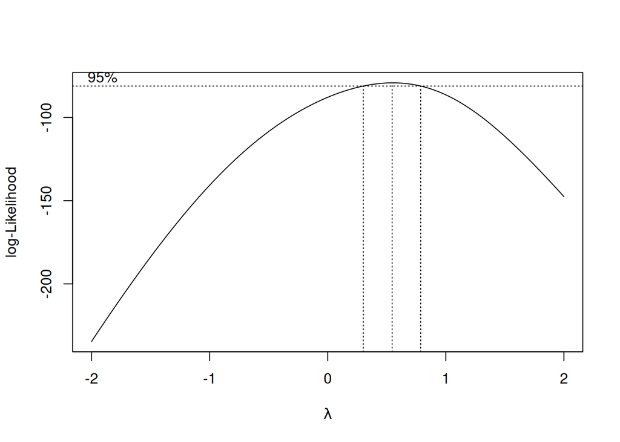

```r
bc <- MASS::boxcox(fit0, lambda = seq(-2, 2, by = 0.05))
```

```r
lambda_hat <- bc$x[which.max(bc$y)]
lambda_hat
```

```
[1] 0.545
```

## 5. Windmill data: transforming the predictor

```r
names(windmill)
```

```
[1] "dc_output"         "wind_velocity"     "wind_velocity_sq"
[4] "wind_velocity_inv"
```

```r
head(windmill)
```

```
  dc_output wind_velocity wind_velocity_sq wind_velocity_inv
1      1.58           5.0            25.00             0.200
2      1.82           6.0            36.00             0.167
3      1.06           3.4            11.56             0.294
4      0.50           2.7             7.29             0.370
5      2.24          10.0           100.00             0.100
6      2.39           9.7            94.09             0.103
```

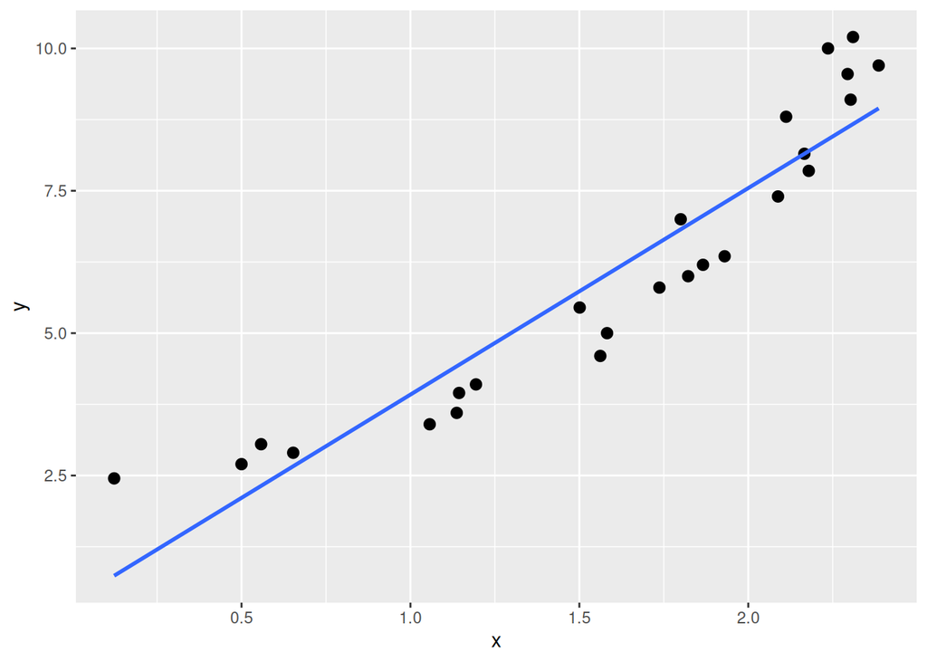

```r
wind <- data.frame(
  x = windmill[[1]],
  y = windmill[[2]]
)

ggplot(wind, aes(x, y)) +
  geom_point(size = 2.5) +
  geom_smooth(method = "lm", se = FALSE)
```

Compare a linear model in (x) with a model in (1/x).

```r
fit_x <- lm(y ~ x, data = wind)
fit_inv <- lm(y ~ I(1 / x), data = wind)

c(
  original_R2 = summary(fit_x)$r.squared,
  inverse_x_R2 = summary(fit_inv)$r.squared
)
```

```
 original_R2 inverse_x_R2
       0.874        0.243
```

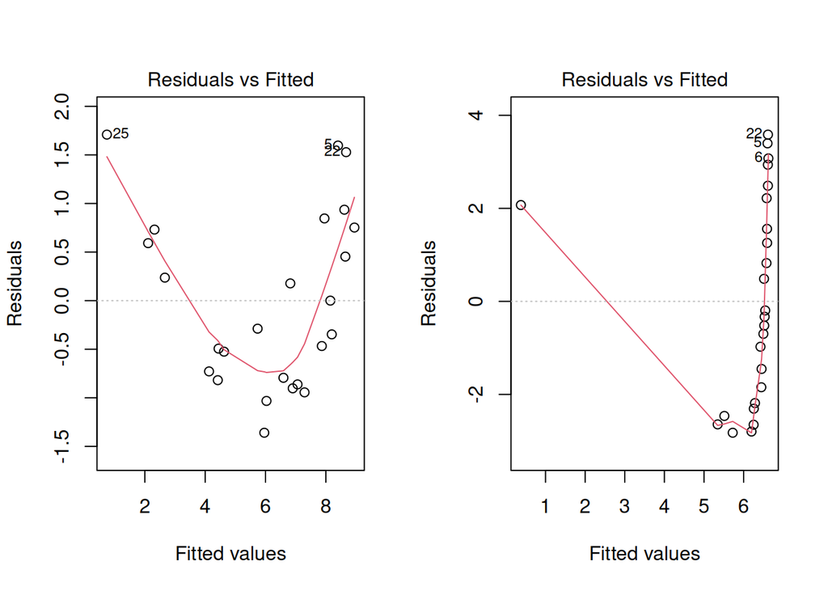

```r
par(mfrow = c(1, 2))
plot(fit_x, which = 1)
plot(fit_inv, which = 1)
```

```r
par(mfrow = c(1, 1))
```

Which representation is easier to justify from the scatterplot and residual plot? Remember that a high (R^2) alone is not enough to establish model adequacy.

## Takeaway

Transformations should be motivated by the scientific relationship and by model diagnostics. They are not simply a device for maximizing (R^2).